# Solar Production EDA

Group E

4/25/2020

This report contains the findings on Solar data, additional data and stations data.

# Preparation

## Load libraries and source data

```r
# General purpose
library(tidyverse)
library(data.table)
library(lubridate)

# Descriptive
library(skimr)

# Visualization
library(knitr)
library(ggplot2)
library(corrplot)
library(PerformanceAnalytics)

# Mapping
library(leaflet)
library(leaflet.extras)
library(sf)

# Calculations
library(forecast)
library(caret)
library(outliers)
```

# Overview: Data structure and content

## 1 General overview

### 1.1 NA check

```r
f_check_na(data_solar_train)$text
```

```
## [1] "No NA in the dataset 'data_solar_train'"
```

```r
f_check_na(data_solar_test)$text
```

```
## [1] "No NA in the dataset 'data_solar_test'"
```

```r
f_check_na(data_station)$text
```

```
## [1] "No NA in the dataset 'data_station'"
```

```r
f_check_na(data_add)$text
```

```
## [1] "There are 3.6% NA in the dataset 'data_add'"
```

> There are no missing values in the solar_dataset and station dataset. There are 26733 NAs values in the ‘additional_dataset’. Those missing values will be estimated using the ‘mice’ library

### 1.2 Constant Variables check

```r
criteria_variables(data_solar_train)
```

```
## [1] "There is no constant variable."
```

```r
criteria_variables(data_solar_test)
```

```
## [1] "There is no constant variable."
```

```r
criteria_variables(data_station)
```

```
## [1] "There is no constant variable."
```

```r
criteria_variables(data_add)
```

```
## [1] "There is no constant variable."
```

> No constant variables have been found.

### 1.3 Outliers check

Based on the following publications:

https://www.kaggle.com/rtatman/data-cleaning-challenge-outliers

https://cran.r-project.org/web/packages/outliers/outliers.pdf

It was calculated the probability of having outliers in the dataset. The following histogram, shows the centered distribution of all the datapoints in the datasets.  
Also, was calculated the distribution per column, with the same result.

#### 1.3.1 Outliers in Solar dataset

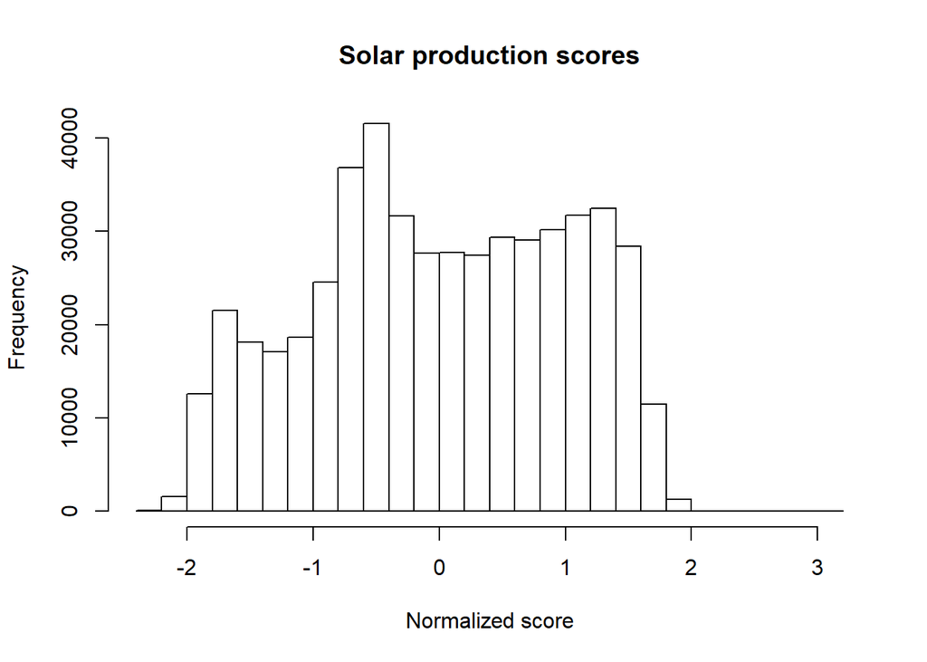

```r
hist(unlist(data_solar_produ_scores), main = 'Solar production scores', xlab = 'Normalized score')
```

## 2 Exploring the columns of Solar dataset

The following functions, shows the stantard statistics for each of the source datasets.  
It’s only being evaluated the first of the chunks, and the first 10 columns. For simplification of the output.

### 2.1 Descriptive statistics of the Training set

```r
skim(data_solar_train[, 1:10])
```

Data summary

| Name | data_solar_train[, 1:10] |
| --- | --- |
| Number of rows | 5113 |
| Number of columns | 10 |
| _______________________ |  |
| Column type frequency: |  |
| character | 1 |
| numeric | 9 |
| ________________________ |  |
| Group variables | None |

**Variable type: character**

| skim_variable | n_missing | complete_rate | min | max | empty | n_unique | whitespace |
| --- | --- | --- | --- | --- | --- | --- | --- |
| Date | 0 | 1 | 8 | 8 | 0 | 5113 | 0 |

**Variable type: numeric**

[output not shown]

```r
glimpse(data_solar_train[, 1:10])
```

```
## Rows: 5,113
## Columns: 10
## $ Date <chr> "19940101", "19940102", "19940103", "19940104", "19940105", "1...
## $ ACME <int> 12384900, 11908500, 12470700, 12725400, 10894800, 6639000, 132...
## $ ADAX <int> 11930700, 9778500, 9771900, 6466800, 11545200, 6817200, 124188...
## $ ALTU <int> 12116700, 10862700, 12627300, 13065300, 8060400, 8157900, 1236...
## $ APAC <int> 12301200, 11666400, 12782700, 12817500, 10379400, 7673100, 128...
## $ ARNE <int> 10706100, 8062500, 11618400, 12134400, 6918600, 3500400, 12181...
## $ BEAV <int> 10116900, 9262800, 10789800, 11816700, 9936300, 2245200, 98778...
## $ BESS <int> 11487900, 9235200, 11895900, 12186600, 6411300, 9719400, 12114...
## $ BIXB <int> 11182800, 3963300, 4512600, 3212700, 9566100, 6137100, 1217520...
## $ BLAC <int> 10848300, 3318300, 5266500, 8270100, 8009400, 4328700, 1183650...
```

### 2.2 Descriptive statistics of the Testing set

```r
skim(data_solar_test)
glimpse(data_solar_test)
```

### 2.3 Descriptive statistics of the Stations dataset

```r
skim(data_station)
glimpse(data_station)
```

### 2.4 Descriptive statistics of Additional information dataset

```r
skim(data_add)
glimpse(data_add)
```

# Descriptive plots

## 1 Principal weather stations

- In this step, weather stations are sorted by their respective solar energy production volume, in descending order. Then, we create 2 plots, the first one shows top weather stations, the second shows the bottom weather stations.
- As shown in the graph below, the differences between stations are small.

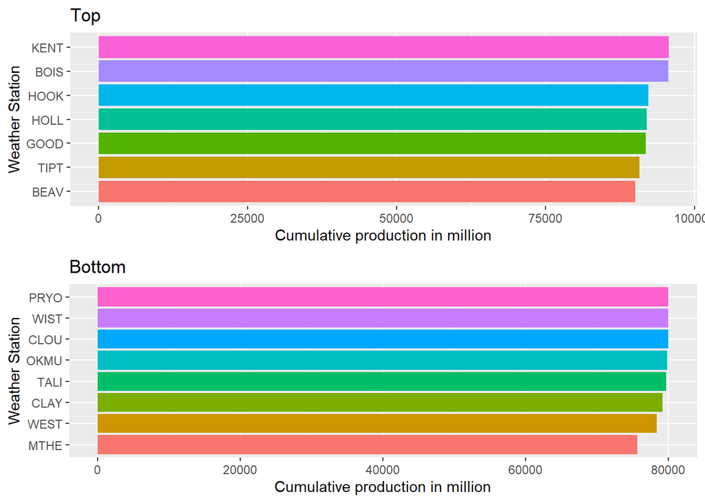

```r
principal_station_plot
```

## 2 Rank position change over time

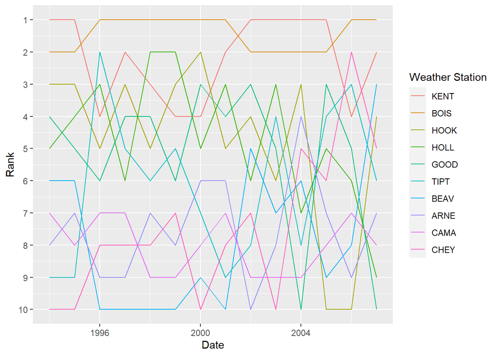

```r
p_rank
```

## 3 Total production seasonality, trend and cyclical movements

Descriptive plot to show the production recorded in millions over different granularities of time.

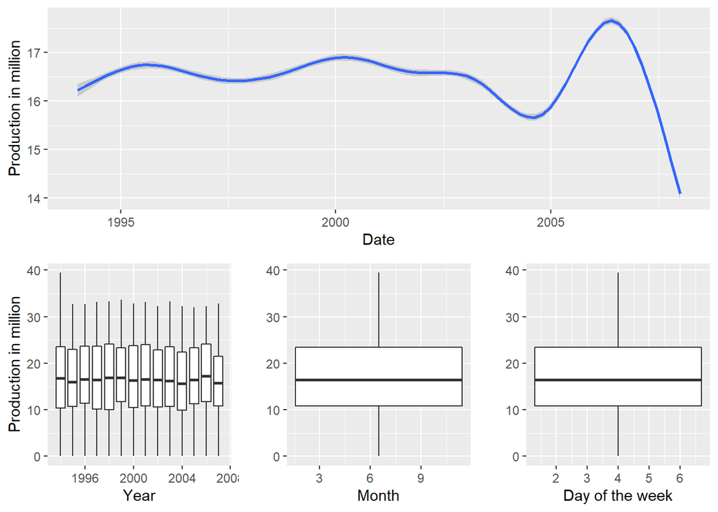

```r
total_production_p
```

## 4 Dive into Seasonality

This section is based on https://towardsdatascience.com/forecasting-with-r-trends-and-seasonality-def24280e71f

- Decomposing the seasonality factor
- First of all, echoing what we have seen in the above section, there is clear seasonality during a year
- Secondly, the trend over the years is more random, there isn’t a pattern (e.g. continuous downward or upward trend) we can observe. Mostly like due to environmental conditions.

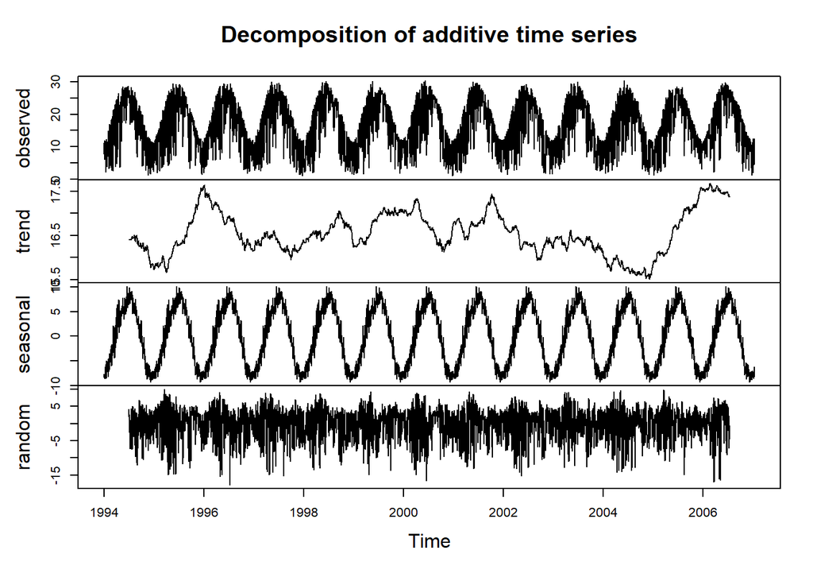

```r
plot(decompose(data2))
```

## 5 Visualizing the production timeseries of the top 5 stations

- Not suprisingly, all stations production trends follow the trend isolated in the graph above.

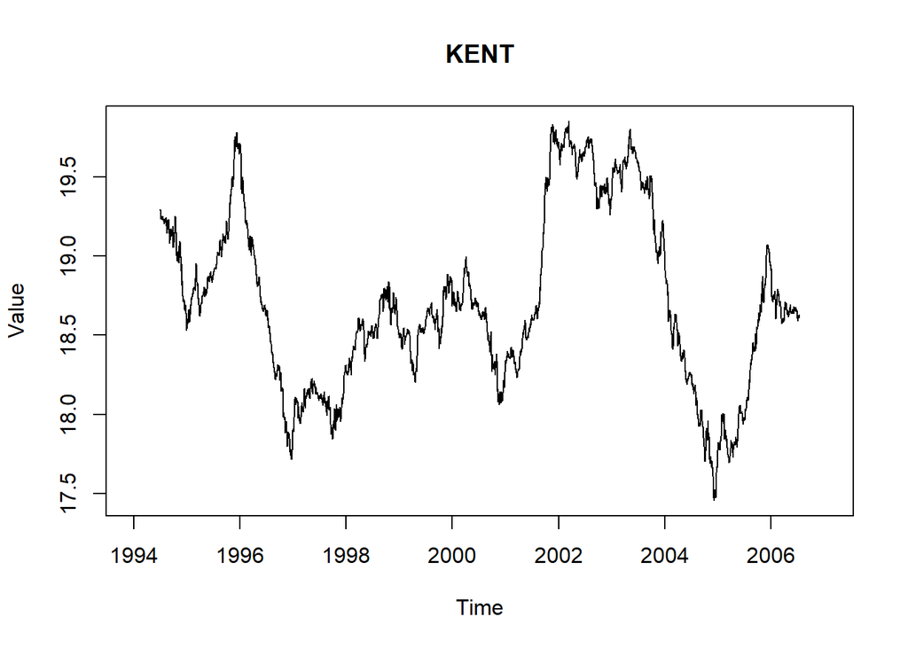

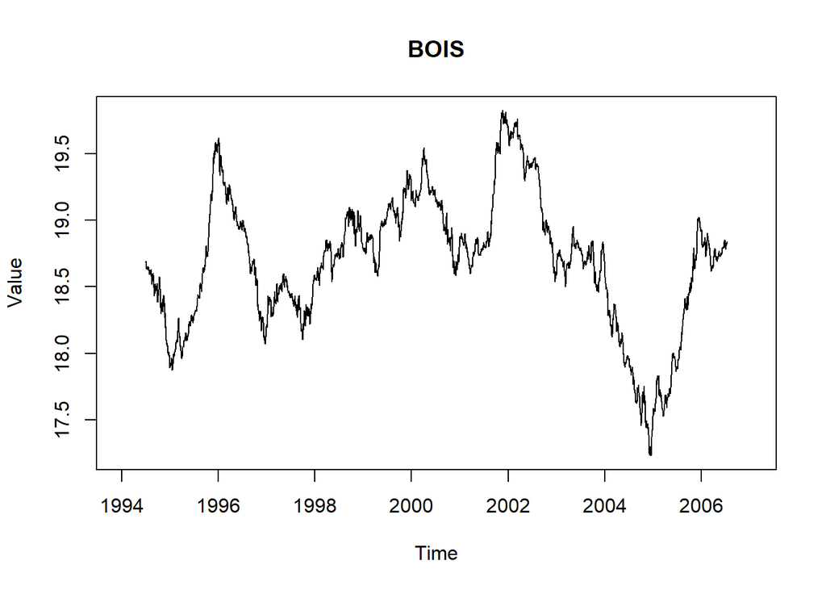

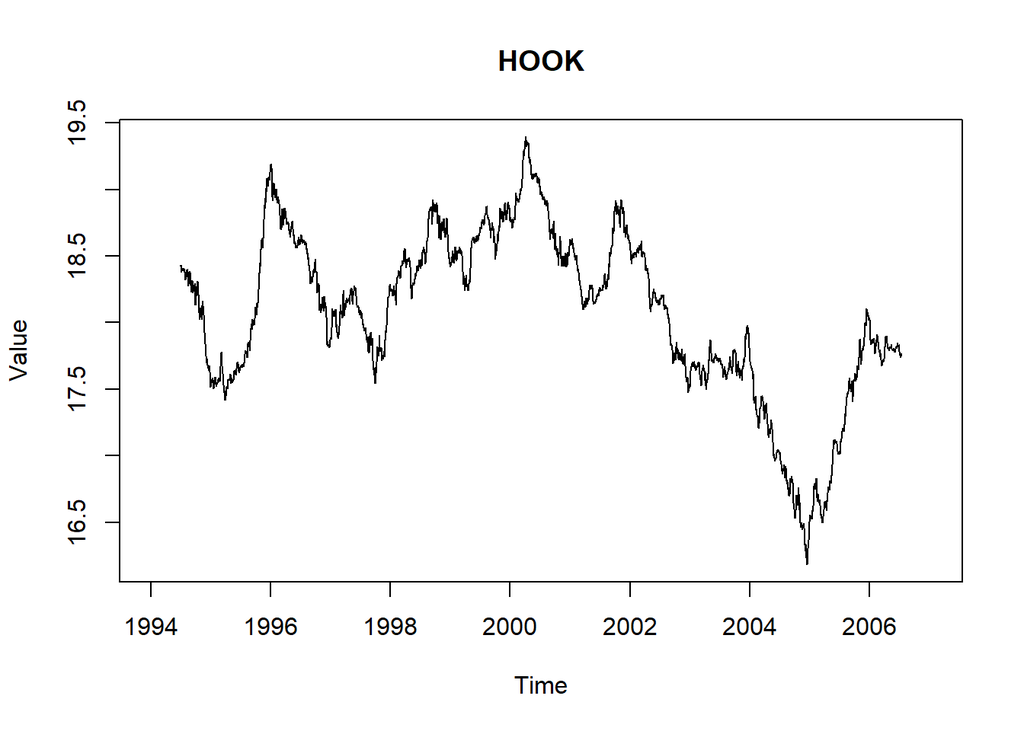

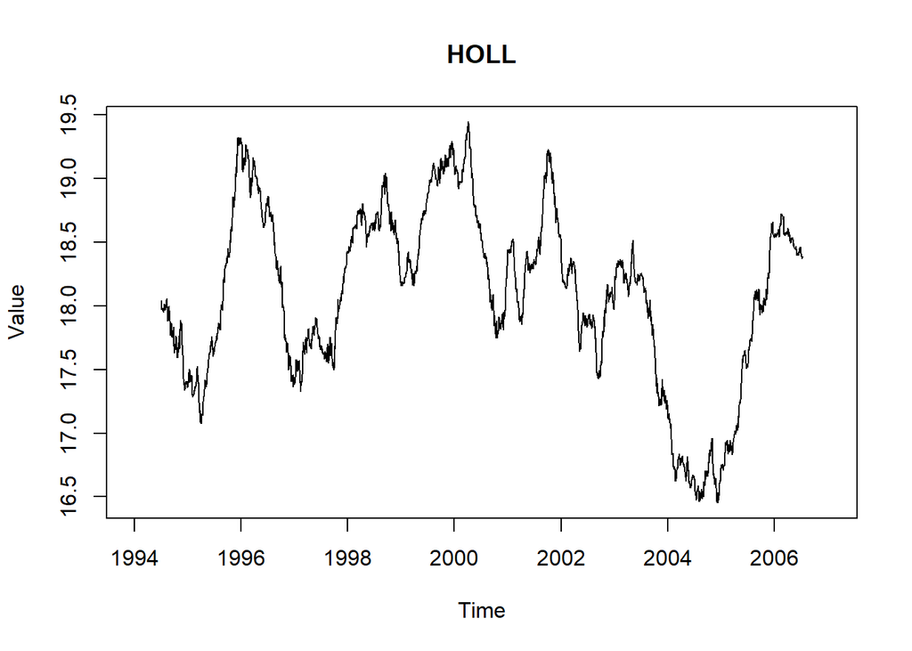

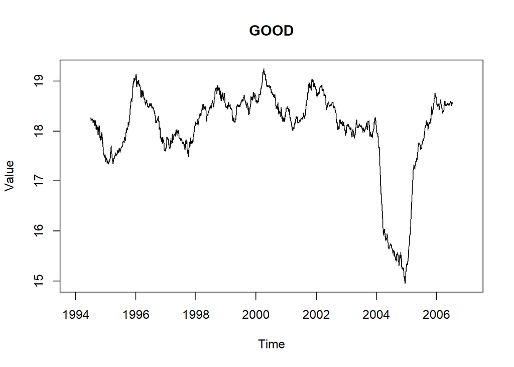

```r
top_ <- 5

ts_ <- function(x) {
  a <- ts(data = x, frequency = 365, start = c(1994, 1, 01), end = c(2007, 12, 31))
  a <- decompose(a)
  return(a)
}

data <- data_solar_train %>%
  pivot_longer(cols = all_of(data_solar_col_produ), names_to = 'WeatherStation', values_to = 'Value') %>%
  group_by(WeatherStation) %>%
  group_map(~ ts_(.x$Value/1e6)) %>%
  setNames(data_solar_col_produ)

p_seasonality_top_5 <- lapply(principal_weather_station[1:top_], function(x) plot(data[[x]]$trend, main = x, ylab = 'Value'))
```

# Geolocalization

## 1 Positions - Where are the stations located?

```r
map_stations
```

[interactive chart not shown]

## 2 Heatmap - Visualizes production volume

```r
map_production
```

[interactive chart not shown]

# Correlations

## 1 Top 5 stations vs first 10 principal components

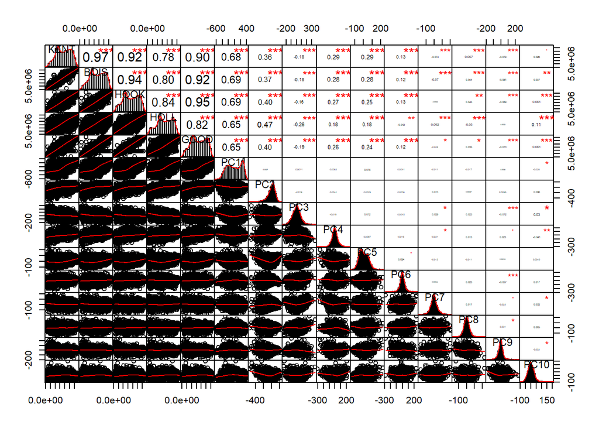

```r
top_ <- 5
top_pc <- 10

data <- data_solar_train %>%
  dplyr::select(principal_weather_station[1:top_], data_solar_col_predi[1:top_pc])

chart.Correlation(data, histogram=TRUE) #, pch=19
```

# Histograms, density kernel and boxplot

## 1 Of general production

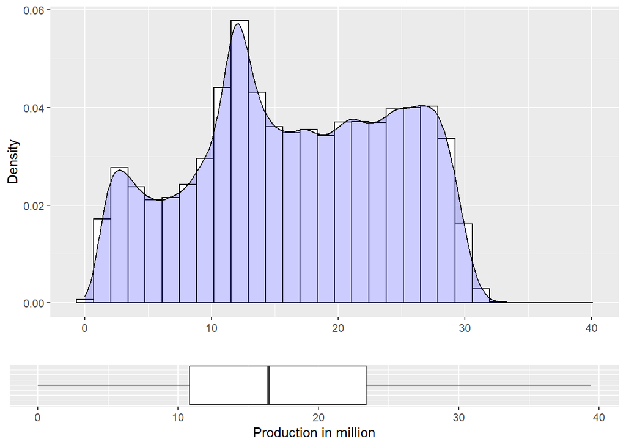

```r
p_distri_prod
```

## 2 Of each weather station

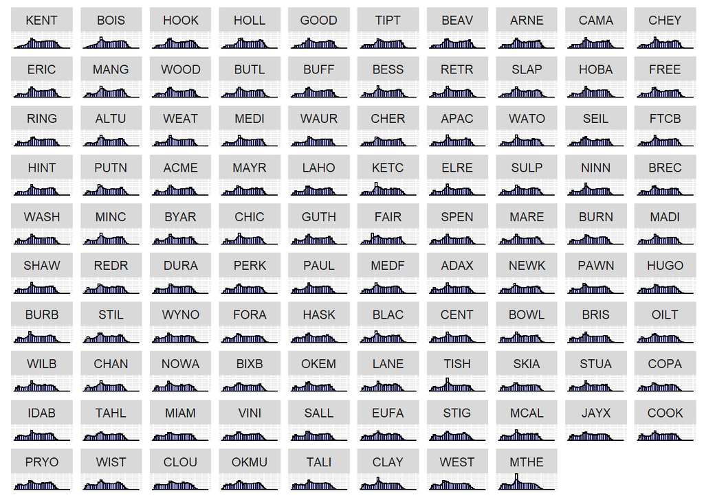

```r
data <- data_solar_train %>%
  select(all_of(data_solar_col_produ)) %>%
  pivot_longer(cols = all_of(data_solar_col_produ), names_to = 'WeatherStation', values_to = 'Value') %>%
  mutate(WeatherStation_f = factor(WeatherStation, levels=principal_weather_station))

ggplot(data = data, aes(x = Value/1e6)) +
  geom_histogram(aes(y=..density..), colour="black", fill="white") +
  geom_density(alpha=.2, fill="blue") +
  facet_wrap(vars(WeatherStation_f)) +
  theme(axis.title.y=element_blank(),
        axis.text.y=element_blank(),
        axis.ticks.y=element_blank(),
        axis.title.x=element_blank(),
        axis.text.x=element_blank(),
        axis.ticks.x=element_blank())
```

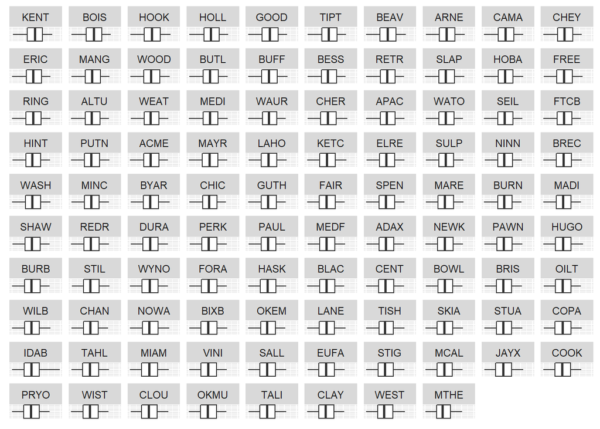

```r
ggplot(data = data, aes(x = Value/1e6)) +
  geom_boxplot() +
  stat_boxplot(coef = 1.5, outlier.colour = 'red', outlier.alpha = 0.1) +
  facet_wrap(vars(WeatherStation_f)) +
  theme(axis.title.y=element_blank(),
        axis.text.y=element_blank(),
        axis.ticks.y=element_blank(),
        axis.title.x=element_blank(),
        axis.text.x=element_blank(),
        axis.ticks.x=element_blank())
```

## 3 Of predictors

- Predictors are highly concentrated, the variances are very small

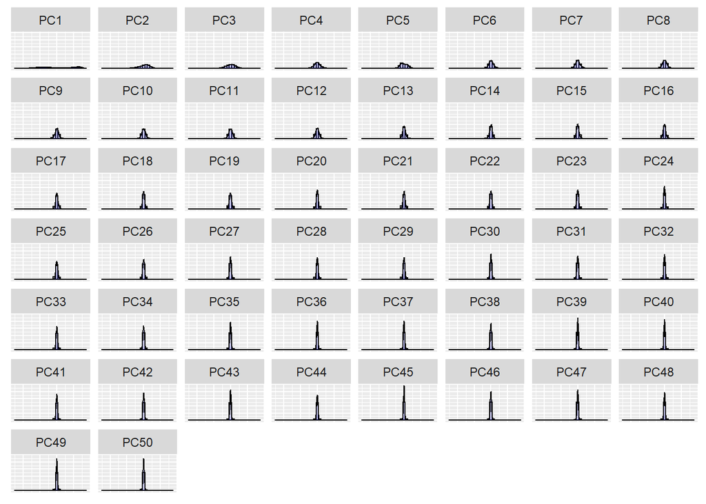

```r
data <- data_solar_train %>%
  select(all_of(data_solar_col_predi)) %>%
  pivot_longer(cols = all_of(data_solar_col_predi), names_to = 'PC', values_to = 'Value') %>%
  filter(PC %in% data_solar_col_predi[1:50]) %>%
  mutate(PC_f = factor(PC, levels=data_solar_col_predi))

ggplot(data = data, aes(x = Value)) +
  geom_histogram(aes(y=..density..), colour="black", fill="white") +
  geom_density(alpha=.2, fill="blue") +
  facet_wrap(vars(PC_f)) +
  theme(axis.title.y=element_blank(),
      axis.text.y=element_blank(),
      axis.ticks.y=element_blank(),
      axis.title.x=element_blank(),
      axis.text.x=element_blank(),
      axis.ticks.x=element_blank())
```

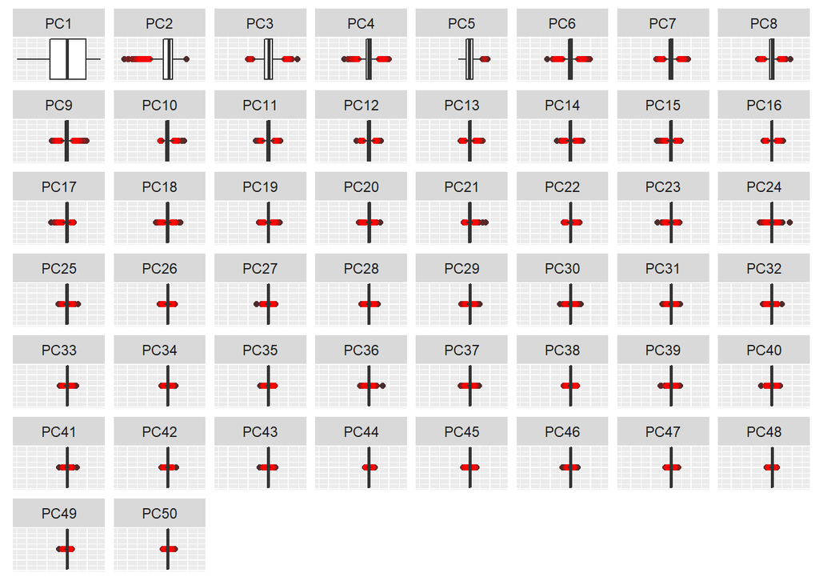

```r
ggplot(data = data, aes(x = Value)) +
  geom_boxplot() +
  stat_boxplot(coef = 1.5, outlier.colour = 'red', outlier.alpha = 0.1) +
  facet_wrap(vars(PC_f)) +
  theme(axis.title.y=element_blank(),
        axis.text.y=element_blank(),
        axis.ticks.y=element_blank(),
        axis.title.x=element_blank(),
        axis.text.x=element_blank(),
        axis.ticks.x=element_blank())
```

# Variable Importance

> Computed Variable Importance is stored in data_solar_importance. Used parallel computing to reduce run time.
- Below is an example of variable importance ranked descendingly, for the top 5 weather station.

```r
top_ <- 5

data_solar_importance <- readRDS(file.path('storage', 'data_solar_importance_parallel.rds'))

names(data_solar_importance) <- principal_weather_station[1:top_]

data_solar_importance[1:top_]
```

```
## $KENT
##  [1] "PC1"   "PC4"   "PC2"   "PC5"   "PC6"   "PC7"   "PC3"   "PC24"  "PC9"
## [10] "PC17"  "PC26"  "PC32"  "PC42"  "PC105" "PC44"  "PC27"  "PC78"  "PC18"
## [19] "PC52"  "PC79"  "PC64"  "PC51"  "PC36"  "PC31"  "PC68"  "PC55"  "PC12"
## [28] "PC33"  "PC57"  "PC47"  "PC35"  "PC29"  "PC49"  "PC63"  "PC104" "PC111"
## [37] "PC8"   "PC69"  "PC40"  "PC71"  "PC37"  "PC60"  "PC171" "PC92"  "PC76"
## [46] "PC86"  "PC113" "PC87"  "PC102" "PC72"
##
## $BOIS
##  [1] "PC1"   "PC2"   "PC4"   "PC5"   "PC6"   "PC3"   "PC7"   "PC24"  "PC9"
## [10] "PC17"  "PC26"  "PC32"  "PC42"  "PC105" "PC78"  "PC79"  "PC44"  "PC18"
## [19] "PC27"  "PC52"  "PC51"  "PC64"  "PC31"  "PC55"  "PC36"  "PC57"  "PC68"
## [28] "PC12"  "PC47"  "PC35"  "PC40"  "PC49"  "PC63"  "PC29"  "PC33"  "PC104"
## [37] "PC71"  "PC69"  "PC102" "PC99"  "PC111" "PC171" "PC37"  "PC19"  "PC72"
## [46] "PC86"  "PC76"  "PC25"  "PC87"  "PC92"
```

[output cut: 24 more lines]

# Additional information dataset

## 1 Distribution of the descriptive stats

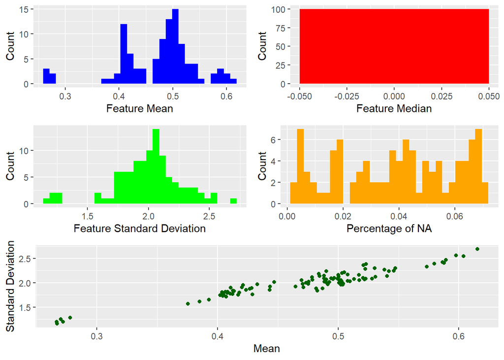

```r
p_additional
```

## 2 Correlation in additional dataset

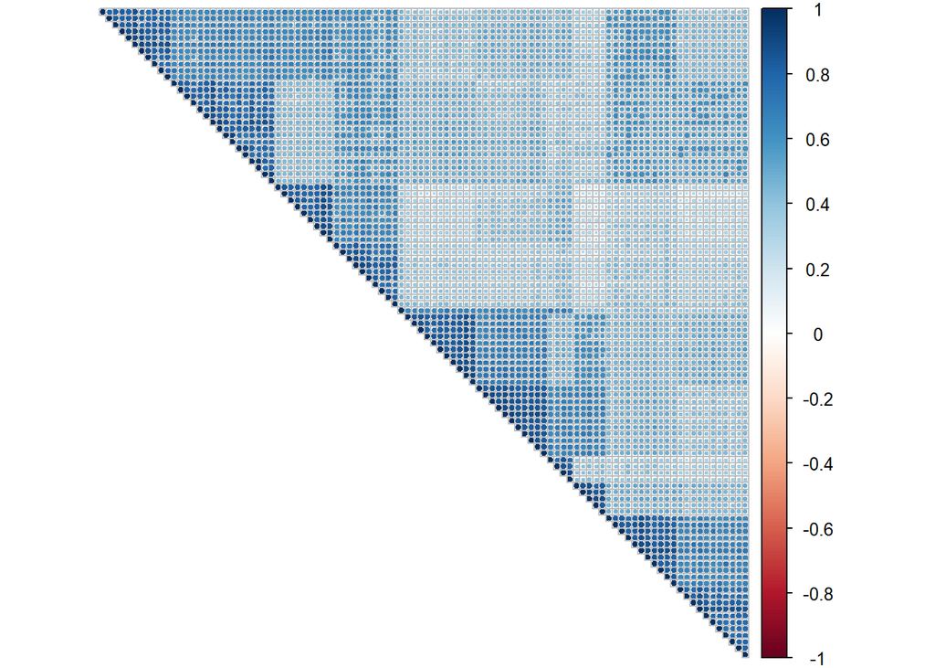

```r
corrplot(cor_, type="upper", order="hclust", p.mat = p.mat, sig.level = 0.01, insig = "blank", tl.pos   = 'n')
```

## 3 PCA of additional dataset

Dimensionality reduction of the additional dataset, using PCA (Principal Component Analysis).

### 3.1 Plot density and boxplots

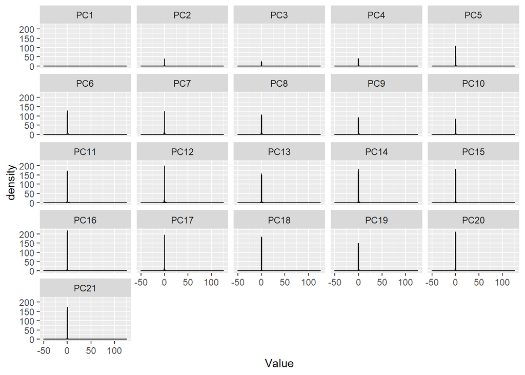

```r
pca_histogram_density
```

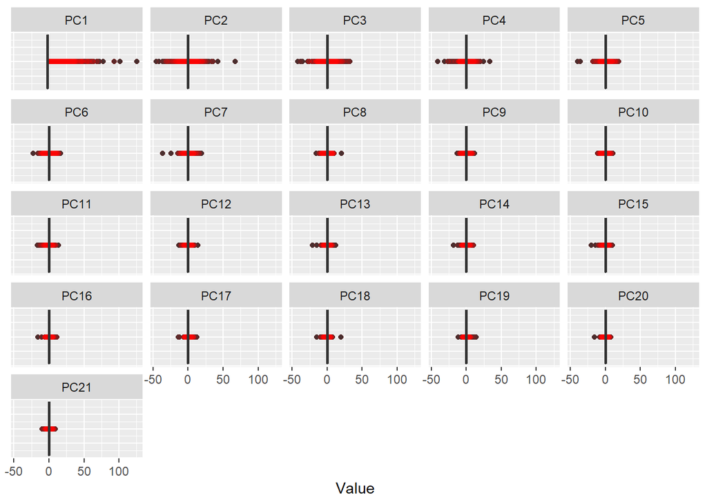

```r
pca_boxplot
```